# Study report

Emile Latour

June 03, 2017

# 1 Introduction

7 cohorts of approximately 5 mice each were given osteosarcoma. Once tumor size grew to approximately 0.2 cm<sup>3</sup>, the mice would begin treatment with one of seven drug treatments. Note that there was no randomization scheme used to assign the mice to different treatments.

Since beginning treatment is dependent on tumor size, mice began treatment at different times. They were all treated and monitored for the same amount of time: 60 days from start of treatment.

In this analysis, we aim to determine if there is a statistically significant difference in the rate of tumor growth between 4 of the groups:

- As,
- B,
- C, and
- D.

# 2 Counts and spaghetti plots

## 2.1 Counts table

Here are the counts of the mice by treatment group.

```r
counts <- valdata %>%
  distinct(id, .keep_all = TRUE) %>%
  janitor::tabyl(treatment) %>%
  janitor::add_totals_row() %>%
  # janitor::adorn_totals("row") %>%
  mutate(percent = round(percent, 2))

knitr::kable(counts,
      col.names = c("Treatment", "Count", "Percent"))
```

| Treatment | Count | Percent |
| --- | --- | --- |
| A | 10 | 0.33 |
| B | 6 | 0.20 |
| C | 6 | 0.20 |
| D | 8 | 0.27 |
| Total | 30 | 1.00 |

## 2.2 Plot by individual with untransformed tumor volume

Plot to see change in tumor volume over time by each individual mouse.

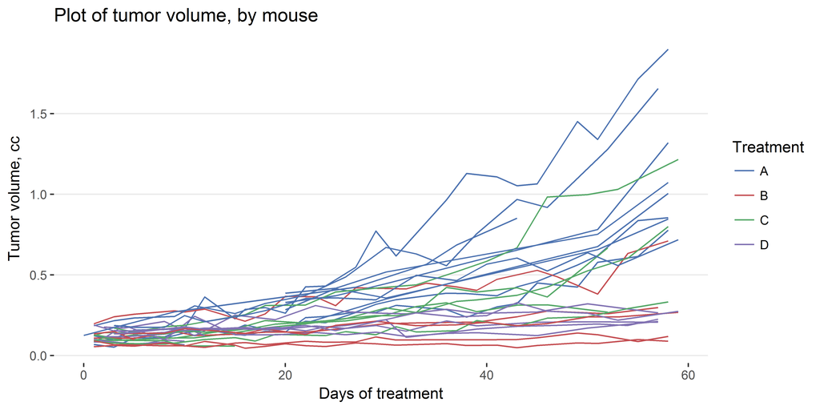

```r
plt <- ggplot(data = valdata,
              aes(x = days, y = vol_cc_sphere, color = trt)) +
  # geom_point(size = 0.8) +
  geom_line(aes(group = id)) +
  labs(title = "Plot of tumor volume, by mouse", x = "Days of treatment",
       y = "Tumor volume, cc") +
  scale_color_manual(name = "Treatment",
                     values = sb_deep) +
  theme_bw() +
  theme(panel.border = element_blank(),
        panel.grid.major.x = element_blank(),
        panel.grid.minor.x = element_blank(),
        panel.grid.minor.y = element_blank(),
        legend.key = element_blank())

suppressWarnings(print(plt))
```

## 2.3 Plot by individual with log<sub>2</sub> transformed tumor volume

Plot to see change in log<sub>2</sub> tumor volume over time by each individual mouse.

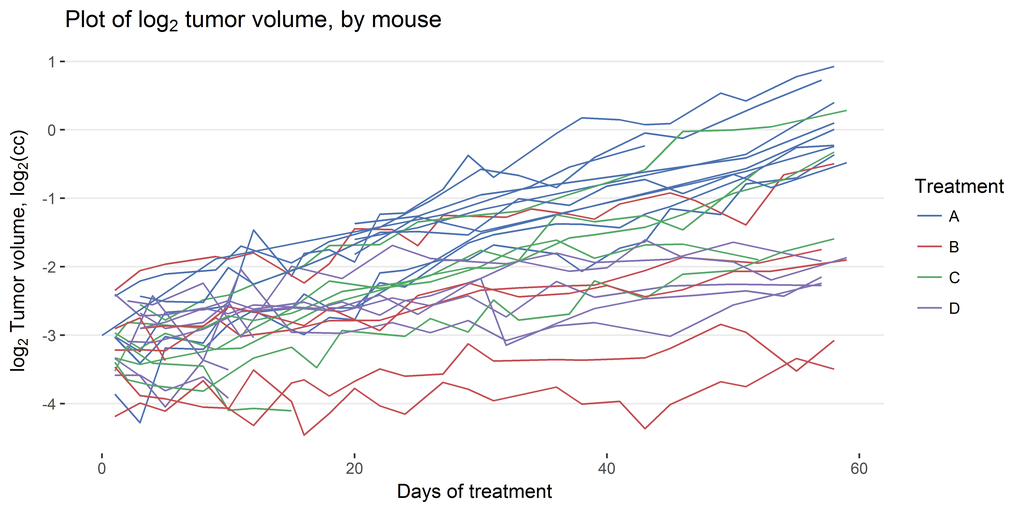

```r
log_plt <- ggplot(data = valdata,
                  aes(x = days, y = vol_log2, color = trt)) +
  # geom_point(size = 0.8) +
  geom_line(aes(group = id)) +
  labs(title = expression("Plot of log"[2]*" tumor volume, by mouse"),
       x = "Days of treatment",
       # y = "Log2 Tumor volume (Log2 cc)") +
       y = expression("log"[2]*" Tumor volume, log"[2]*"(cc)")) +
  scale_color_manual(name = "Treatment",
                     values = sb_deep) +
  theme_bw() +
  theme(panel.border = element_blank(),
        panel.grid.major.x = element_blank(),
        panel.grid.minor.x = element_blank(),
        panel.grid.minor.y = element_blank(),
        legend.key = element_blank())

suppressWarnings(print(log_plt))
```

# 3 Linear mixed effects model

The table below shows the results of the fixed effects from the linear mixed effects model specified in the Appendix. Note that the time variable `Days` is statistically significant at the $\alpha$ = 0.05 level. As are the interaction terms for B and for D.

```r
# Random slope model fit with lmerTest

log_tumor_mod <-
  lmerTest::lmer(vol_log2 ~ trt * days + (days | id), data = valdata)

# Get just the coefficient matrix from the output

tidy_mod <- (summary(log_tumor_mod))$coefficients

tm_rownames <- c("Intercept", "TRT = B", "TRT = C",
                 "TRT = D", "Days", "(TRT = B) * Days",
                 "(TRT = C) * Days", "(TRT = D) * Days")

# Coerce to a data frame

tidy_mod <- as.data.frame(tidy_mod, row.names = tm_rownames)

# Format the p-values

# dim(tidy_mod)
# tidy_mod[, 5]

tidy_mod[, 5] <- format.pval(tidy_mod[ , 5], eps = .001, digits = 2)

# format the rest of the numbers

tidy_mod[, -5] <- round(tidy_mod[, -5], digits = 3)

# Add some indication of signicant p-value

tidy_mod$Sig <- ifelse(tidy_mod[, 5] < 0.05, "***", "")

knitr::kable(tidy_mod)
```

|  | Estimate | Std. Error | df | t value | Pr(>\|t\|) | Sig |
| --- | --- | --- | --- | --- | --- | --- |
| Intercept | -2.896 | 0.165 | 28.379 | -17.507 | <0.001 | *** |
| TRT = B | -0.359 | 0.264 | 26.077 | -1.364 | 0.1842 |  |
| TRT = C | -0.473 | 0.264 | 26.098 | -1.794 | 0.0844 |  |
| TRT = D | -0.103 | 0.244 | 26.784 | -0.420 | 0.6775 |  |
| Days | 0.052 | 0.005 | 10.817 | 11.433 | <0.001 | *** |
| (TRT = B) * Days | -0.034 | 0.008 | 10.049 | -4.458 | 0.0012 | *** |
| (TRT = C) * Days | -0.016 | 0.008 | 10.709 | -2.092 | 0.0611 |  |
| (TRT = D) * Days | -0.044 | 0.007 | 11.322 | -5.856 | <0.001 | *** |

# 4 Compare and test the treatment groups

Using the model results, test whether the rate of change in log<sub>2</sub> tumor volume is the same between the groups. Then test the groups in pairs.

## 4.1 Plot of log<sub>2</sub> tumor volume, by group with fitted lines

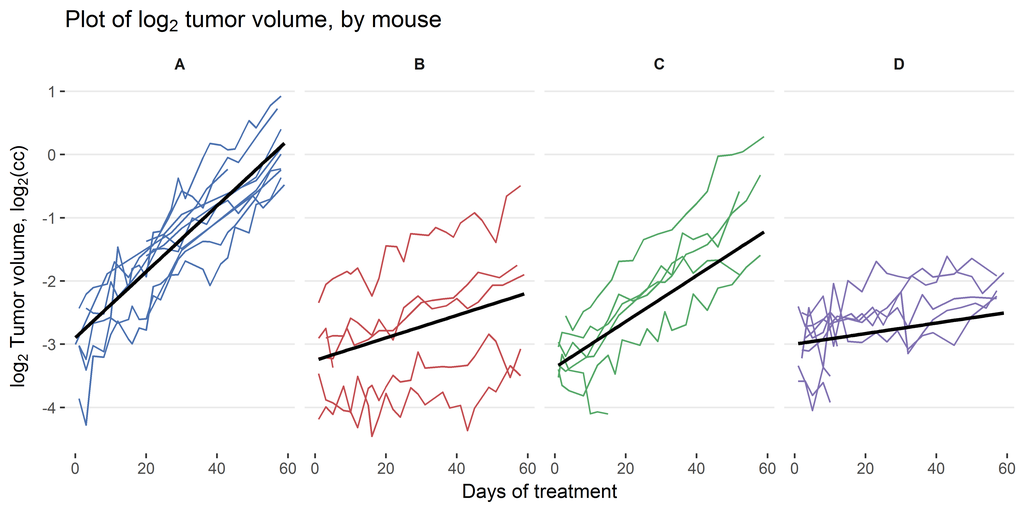

```r
gg <- ggplot(data = valdata,
             aes(x = days, y = vol_log2, color = treatment)) +
  geom_line(aes(group = id)) +
  labs(title = expression("Plot of log"[2]*" tumor volume, by mouse"),
       x = "Days of treatment",
       # y = "Log2 Tumor volume (Log2 cc)") +
       y = expression("log"[2]*" Tumor volume, log"[2]*"(cc)")) +
  scale_color_manual(name = "Treatment",
                     values = sb_deep) +
  geom_line(data = valdata,
            aes(x = days, y = draw),
            color = "black",
            size = 0.9) +
  facet_wrap(~ treatment, nrow = 1) +
  theme_bw() +
  theme(panel.border = element_blank(),
        panel.grid.major.x = element_blank(),
        panel.grid.minor.x = element_blank(),
        panel.grid.minor.y = element_blank(),
        legend.key = element_blank(),
        legend.position = "none") +
  theme(strip.background = element_blank(),
           strip.text = element_text(face = "bold"))


suppressWarnings(print(gg))
```

## 4.2 Plot of (back-transformed) tumor volume, by group with fitted lines

Here is a plot of the original data by group with fitted regression lines on the same scale.

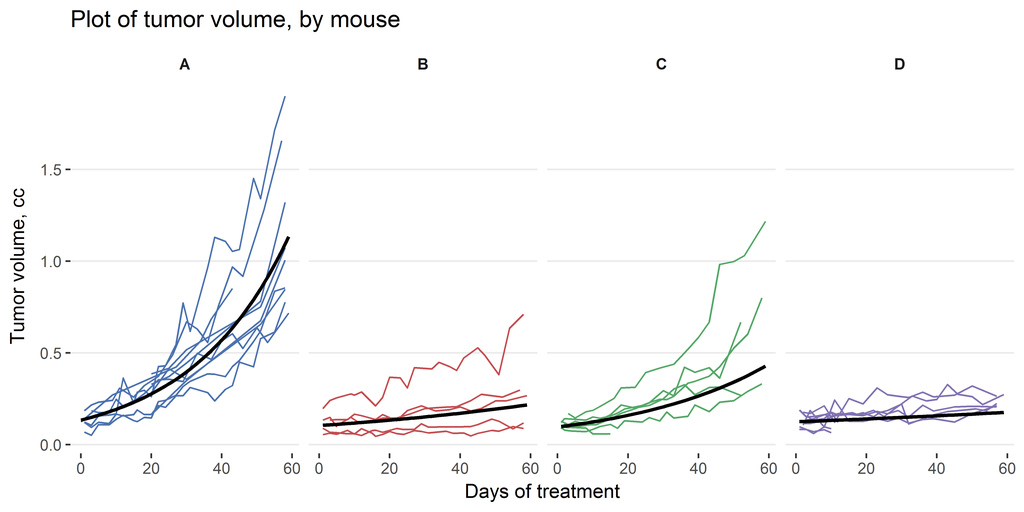

```r
gg_exp <- ggplot(data = valdata,
                 aes(x = days, y = vol_cc_sphere, color = treatment)) +
  geom_line(aes(group = id)) +
  labs(title = expression("Plot of tumor volume, by mouse"),
       x = "Days of treatment",
       y = expression("Tumor volume, cc")) +
  scale_color_manual(name = "Treatment",
                     values = sb_deep) +
  geom_line(data = valdata,
            aes(x = days, y = draw_exp),
            color = "black",
            size = 0.9) +
  facet_wrap(~ treatment, nrow = 1) +
  theme_bw() +
  theme(panel.border = element_blank(),
        panel.grid.major.x = element_blank(),
        panel.grid.minor.x = element_blank(),
        panel.grid.minor.y = element_blank(),
        legend.key = element_blank(),
        legend.position = "none") +
  theme(strip.background = element_blank(),
           strip.text = element_text(face = "bold"))


suppressWarnings(print(gg_exp))
```

## 4.3 Test that slopes are the same for all treatment groups

See Appendix for statement of hypothesis test.

### 4.3.1 Conclusion:

Based on the data for the study mice, we reject the null hypothesis that the rates of change in log<sub>2</sub> tumor volume are equal for the 4 treatment groups ($\chi^2_{df=3}$ = 41.17; *p*-value < 0.001). We conclude that there is a statistically significant difference in the rate of change in log<sub>2</sub> tumor volume for at least one of the treatment groups compared to the rest.

## 4.4 Compare the slopes between each of the groups

Since we determined above that the rate of change in log<sub>2</sub> tumor volume is different for at least one of the treatment groups, we will test each group against one another to determine which groups are different.

See the Appendix for the stated linear contrasts.

### 4.4.1 Summary of slopes

```r
D_vs_B = matrix(data = c(0, 0, 0, 0, 0, 1, 0, -1), nrow = 1)
D_vs_C = matrix(data = c(0, 0, 0, 0, 0, 0, 1, -1), nrow = 1)
D_vs_A = matrix(data = c(0, 0, 0, 0, 0, 0, 0, -1), nrow = 1)
B_vs_C = matrix(data = c(0, 0, 0, 0, 0, -1, 1, 0), nrow = 1)
B_vs_A = matrix(data = c(0, 0, 0, 0, 0, -1, 0, 0), nrow = 1)
C_vs_A = matrix(data = c(0, 0, 0, 0, 0, 0, -1, 0), nrow = 1)


l1 <- lincom(B_vs_A, log_tumor_mod)
l2 <- lincom(C_vs_A, log_tumor_mod)
l3 <- lincom(D_vs_A, log_tumor_mod)
l4 <- lincom(B_vs_C, log_tumor_mod)
l5 <- lincom(D_vs_B, log_tumor_mod)
l6 <- lincom(D_vs_C, log_tumor_mod)

l_cs <- rbind(l1, l2, l3, l4, l5, l6)
rm(l1, l2, l3, l4, l5, l6)

rownames(l_cs) <- c("B vs. A",
                    "C vs. A",
                    "D vs. A",
                    "B vs. C",
                    "D vs. B",
                    "D vs. C")

# format some of the output
l_cs[, -4] <- round(l_cs[, -4], digits = 4)

# Add some indication of signicant p-value
l_cs$Sig <- ifelse(as.numeric(as.character(l_cs[, 4])) > 0.05 / 6,
                             "", "***")

l_cs[, 4] = format.pval(l_cs[, 4], eps = .001, digits = 2)

knitr::kable(l_cs)
```

|  | Coef | Std_Err | z | p_value | LL_95CI | UL_95CI | Sig |
| --- | --- | --- | --- | --- | --- | --- | --- |
| B vs. A | 0.0343 | 0.0077 | 4.458 | <0.001 | 0.0192 | 0.0494 | *** |
| C vs. A | 0.0158 | 0.0075 | 2.092 | 0.036 | 0.0010 | 0.0306 |  |
| D vs. A | 0.0438 | 0.0075 | 5.856 | <0.001 | 0.0291 | 0.0585 | *** |
| B vs. C | 0.0185 | 0.0086 | 2.147 | 0.032 | 0.0016 | 0.0355 |  |
| D vs. B | 0.0095 | 0.0086 | 1.104 | 0.270 | -0.0073 | 0.0263 |  |
| D vs. C | 0.0280 | 0.0084 | 3.319 | <0.001 | 0.0115 | 0.0446 | *** |

# 5 Appendix

## 5.1 Linear mixed effects model

### 5.1.1 Model specification

As are treated as the baseline group.

$$\begin{align*}
\mathrm{log_2(VOL)} &= \beta_0 \\
&+ \beta_{1} \mathrm{TRT}_{B} \\
&+ \beta_{2} \mathrm{TRT}_{C} \\
&+ \beta_{3} \mathrm{TRT}_{D} \\
&+ \beta_{4} \mathrm{DAYS} \\
&+ \beta_{5} \mathrm{TRT}_{B}\times \mathrm{DAYS} \\
&+ \beta_{6} \mathrm{TRT}_{C}\times \mathrm{DAYS} \\
&+ \beta_{7} \mathrm{TRT}_{D}\times \mathrm{DAYS} \\
&+ \mu_{0j} \\
&+ \mu_{1}\times \mathrm{DAYS}_{ij} \\
&+ \epsilon_{ij}
\end{align*}$$

### 5.1.2 Model output

```r
summary(log_tumor_mod)
```

```
Linear mixed model fit by REML t-tests use Satterthwaite approximations
  to degrees of freedom [lmerMod]
Formula: vol_log2 ~ trt * days + (days | id)
   Data: valdata

REML criterion at convergence: 149.5

Scaled residuals:
    Min      1Q  Median      3Q     Max
-3.4100 -0.5601  0.0348  0.5655  3.8479

Random effects:
 Groups   Name        Variance  Std.Dev. Corr
 id       (Intercept) 0.2422701 0.49221
          days        0.0001863 0.01365  0.12
 Residual             0.0489029 0.22114
Number of obs: 438, groups:  id, 30

Fixed effects:
             Estimate Std. Error        df t value Pr(>|t|)
(Intercept) -2.895665   0.165398 28.379000 -17.507  < 2e-16 ***
trtB        -0.359483   0.263526 26.077000  -1.364   0.1842
trtC        -0.472905   0.263566 26.098000  -1.794   0.0844 .
trtD        -0.102501   0.243818 26.784000  -0.420   0.6775
days         0.052146   0.004561 10.817000  11.433 2.23e-07 ***
trtB:days   -0.034331   0.007701 10.049000  -4.458   0.0012 **
trtC:days   -0.015782   0.007545 10.709000  -2.092   0.0611 .
trtD:days   -0.043804   0.007480 11.322000  -5.856 9.80e-05 ***
---
Signif. codes:  0 '***' 0.001 '**' 0.01 '*' 0.05 '.' 0.1 ' ' 1

Correlation of Fixed Effects:
          (Intr) trtB   trtC   trtD   days   trtB:d trtC:d
trtB      -0.628
trtC      -0.628  0.394
trtD      -0.678  0.426  0.426
days       0.011 -0.007 -0.007 -0.007
trtB:days -0.006  0.045  0.004  0.004 -0.592
trtC:days -0.007  0.004  0.040  0.004 -0.604  0.358
trtD:days -0.007  0.004  0.004  0.007 -0.610  0.361  0.369
```

```r
anova(log_tumor_mod)
```

```
Analysis of Variance Table of type III  with  Satterthwaite
approximation for degrees of freedom
         Sum Sq Mean Sq NumDF  DenDF F.value    Pr(>F)
trt      0.2020  0.0673     3 25.690   1.377 0.2720953
days     4.9241  4.9241     1 10.613 100.692 9.564e-07 ***
trt:days 2.0133  0.6711     3 10.631  13.723 0.0005585 ***
---
Signif. codes:  0 '***' 0.001 '**' 0.01 '*' 0.05 '.' 0.1 ' ' 1
```

## 5.2 Equations for each treatment group

### 5.2.1 Treatment = A

$$\mathrm{log_2(VOL)} = \beta_0 + \beta_{4} \mathrm{DAYS}$$

### 5.2.2 Treatment = B

$$\mathrm{log_2(VOL)} = (\beta_0 + \beta_{1}) + (\beta_{4}+ \beta_{5}) \mathrm{DAYS}$$

### 5.2.3 Treatment = C

$$\mathrm{log_2(VOL)} = (\beta_0 + \beta_{2}) + (\beta_{4}+ \beta_{6}) \mathrm{DAYS}$$

### 5.2.4 Treatment = D

$$\mathrm{log_2(VOL)} = (\beta_0 + \beta_{3}) + (\beta_{4}+ \beta_{7}) \mathrm{DAYS}$$

### 5.2.5 Slopes and intercepts for each treatment group

```r
knitr::kable(trt_lines)
```

| treatment | intercepts | slopes |
| --- | --- | --- |
| A | -2.895665 | 0.0521460 |
| B | -3.255148 | 0.0178150 |
| C | -3.368570 | 0.0363640 |
| D | -2.998166 | 0.0083422 |

## 5.3 Hypothesis test of equal slope for each treatment group

### 5.3.1 Hypothesis

$$H_0: \beta_4 = (\beta_4 + \beta_5) = (\beta_4 + \beta_6) = (\beta_4 + \beta_7)$$
$$vs.$$
$$H_{A}: At\ least\ one\ slope\ is\ different\ than\ the\ rest.$$

Or, alternatively:

$$H_0: \beta_5 = \beta_6 = \beta_7 = 0$$

$$vs.$$

$$H_{A}: At\ least\ one\ slope\ is\ different\ than\ the\ rest.$$

### 5.3.2 Output of test

```r
test_all
```

```
Analysis of Deviance Table (Type II Wald chisquare tests)

Response: vol_log2
            Chisq Df Pr(>Chisq)
trt        3.9342  3     0.2687
days     136.3783  1  < 2.2e-16 ***
trt:days  41.1688  3  6.022e-09 ***
---
Signif. codes:  0 '***' 0.001 '**' 0.01 '*' 0.05 '.' 0.1 ' ' 1
```

## 5.4 Linear contrasts of the treatment groups

### 5.4.1 D vs. B

$$\beta_4 + \beta_5= \beta_4 + \beta_7 \Leftrightarrow \beta_5 - \beta_7 = 0$$

$$\beta_4 + \beta_6 = \beta_4 + \beta_7 \Leftrightarrow \beta_6 - \beta_7 = 0$$

### 5.4.3 D vs. A

$$\beta_4 = \beta_4 + \beta_7 \Leftrightarrow -\beta_7 = 0$$

$$\beta_4 + \beta_5= \beta_4 + \beta_6 \Leftrightarrow \beta_5 - \beta_6 = 0$$

### 5.4.5 B vs. A

$$\beta_4 + \beta_5 = \beta_4 \Leftrightarrow \beta_5 = 0$$

$$\beta_4 + \beta_6 = \beta_4 \Leftrightarrow \beta_6 = 0$$